# Praca domowa 2

Aleksandra Iwaniuk

## Dane

Dane wykorzystane w Pracy domowej 2 są związane z kampaniami marketingu bezpośredniego portugalskiej instytucji bankowej. Kampanie marketingowe opierały się na rozmowach telefonicznych. Często wymagany był więcej niż jeden kontakt z tym samym klientem, aby uzyskać dostęp do tego, czy produkt (lokata bankowa) zostanie (lub nie) subskrybowany. Opis wszystkich kolumn znajduje się również w pliku `README.md`.

#### Dane klienta banku

| Zmienna | Opis |
| --- | --- |
| **age** | wiek |
| **job** : admin., unknown, unemployed, management, housemaid, entrepreneur, student, blue-collar, self-employed, retired, technician, services | administrator, nieznany, bezrobotny, kierownictwo, pokojówka, przedsiębiorca, student, pracownik fizyczny, samozatrudniony, emeryt, technik, usługi |
| **marital** : married, divorced, single; note: divorced means divorced or widowed) | żonaty/zamężna, rozwiedzion_, kawaler/panna; uwaga: rozwiedzion_ oznacza rozwiedzion_ lub owdowiał_ |
| **education** : unknown, secondary, primary, tertiary | nieznane, średnie, podstawowe, wyższe |
| **default** : yes, no | czy kredyt jest niespłacany : tak, nie |
| **balance** : average yearly balance, in euros | średnie roczne saldo w euro |
| **housing** : has housing loan? yes, no | czy posiada kredyt mieszkaniowy? tak, nie |
| **loan** : has personal loan? yes, no | ma pożyczkę osobistą? tak, nie |

#### Dane związane z ostatnim kontaktem w bieżącej kampanii

| Zmienna | Opis |
| --- | --- |
| **contact** : unknown, telephone, cellular | nieznany, telefon, komórkowy |
| **day** : last contact day of the month | dzień miesiąca ostatniego kontaktu |
| **month** : last contact month of year, jan, feb, mar, …, nov, dec | miesiąc ostatniego kontaktu w roku, styczeń, luty, marzec, …, listopad, grudzień |
| **duration** : last contact duration, in seconds | czas trwania ostatniego kontaktu w sekundach |

## Zadanie 1

Weźmy pod uwagę zawody (`job`) klientów banku. Który zawód zacząco wyróżnia się w posiadaniu kredytu mieszkaniowego lub pożyczki osobistej?

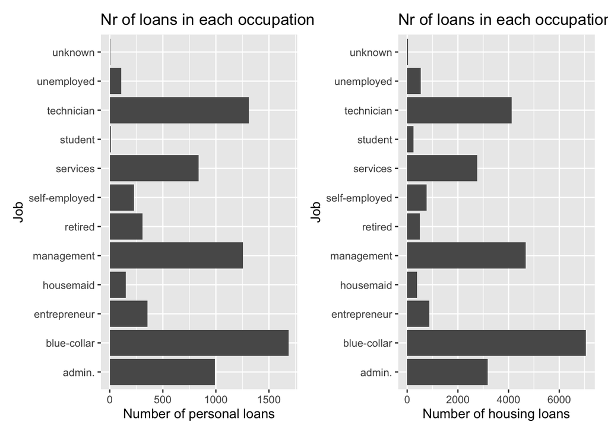

```r
plot_1 <-df %>%
  filter(loan == 'yes') %>%
  ggplot(mapping = aes(x = as.factor(job))) +
  geom_bar() +
  coord_flip() +
  labs(x = 'Job',
       y = 'Number of personal loans',
       title='Nr of loans in each occupation')

plot_2 <-df %>%
  filter(housing == 'yes') %>%
  ggplot(mapping = aes(x = as.factor(job))) +
  geom_bar() +
  coord_flip() +
  labs(x = 'Job',
       y = 'Number of housing loans',
       title='Nr of loans in each occupation')
plot_1 + plot_2
```

**Komentarz:**

Zawód “blue-collar” wyróżnia się znacząco w posiadaniu kredytu mieszkaniowego jak i osobistego, liczba osób w tej grupie zawodowej w obu przypadkach jest najwyższa spośród wszystkich zawodów. Zarówno w przypadku kredytu osobistego jak i mieszkaniowego grupy “technician”, “management” i “admin” mają wyraźnie więcej pożyczek niż pozostałe.

## Zadanie 2

Wybierając klientów, którzy mają nieznany sposób kontaktu (`contact`). Jak rozkłada się ich wiek w podziale na status związku?

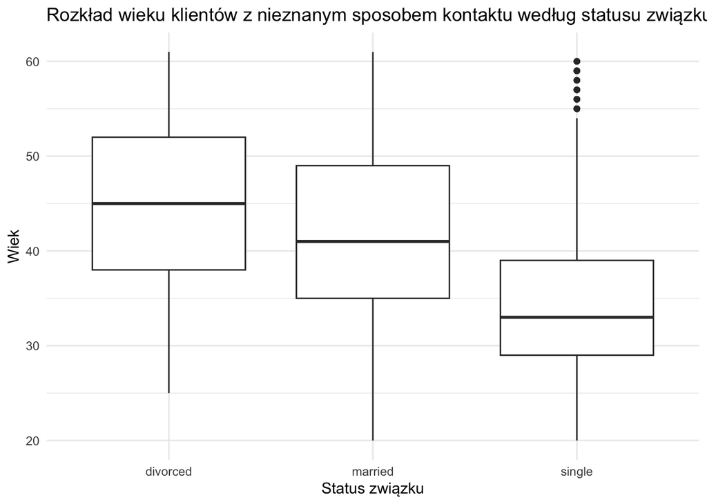

```r
df %>%
  filter(contact=='unknown'|is.na(contact)) %>%
  ggplot(aes(x = marital, y = age)) +
  geom_boxplot() +
  labs(title = "Rozkład wieku klientów z nieznanym sposobem kontaktu według statusu związku",
       x = "Status związku",
       y = "Wiek") +
  theme_minimal()
```

**Komentarz:**

Widzimy też kilka wartości odstających (outlierów), co pokazuje nam, że bardzo mała grupa starszych klientów jest samotna.

W grupie kientów rozwiedzionych (“divorced”) widziamy, że nie ma osób bardzo młodych, a w gupie osób w związku małżeńskim (“married”) rozkład jest najszerszy.

## Zadanie 3

Jaka jest różnica pomiędzy średnim rocznym saldem w euro w zależności od wykształcenia i tego czy kredyt jest niespłacany?

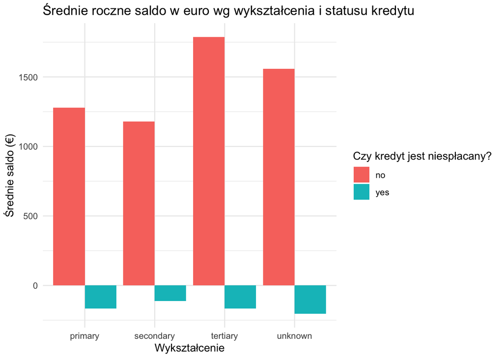

```r
df %>%
  group_by(education, default) %>%
  summarise(mean_balance = mean(balance, na.rm = TRUE)) %>%
  ungroup() %>%
   ggplot(aes(x = education, y = mean_balance, fill = default)) +
  geom_col(position = "dodge") +
  labs(title = "Średnie roczne saldo w euro wg wykształcenia i statusu kredytu",
       x = "Wykształcenie",
       y = "Średnie saldo (€)",
       fill = "Czy kredyt jest niespłacany?") +
  theme_minimal()
```

**Komentarz:**

Niezależnie od poziomu wykształcenia osoby, które spłacają kredyt (“no”) mają znacznie wyższe średnie roczne saldo w porównaniu do osób które go nie spłacają (“yes”)

Moźemy zauważyć, że średnie saldo osób niespłacających kredytu jest ujemne, podczas gdy dla osób, które spłacają kredyt, saldo jest dodatnie.

Najwyższe saldo wśród osob spłacających kredyt mają osoby o wykształceniu wyższym, najniższe osoby o wykształceniu średnim.

## Zadanie 4

Czy dzień i miesiąc kontaktu z klientem ma wpływ na średni czas trwania rozmowy w stosunku do średniego czasu trwania rozmowy?

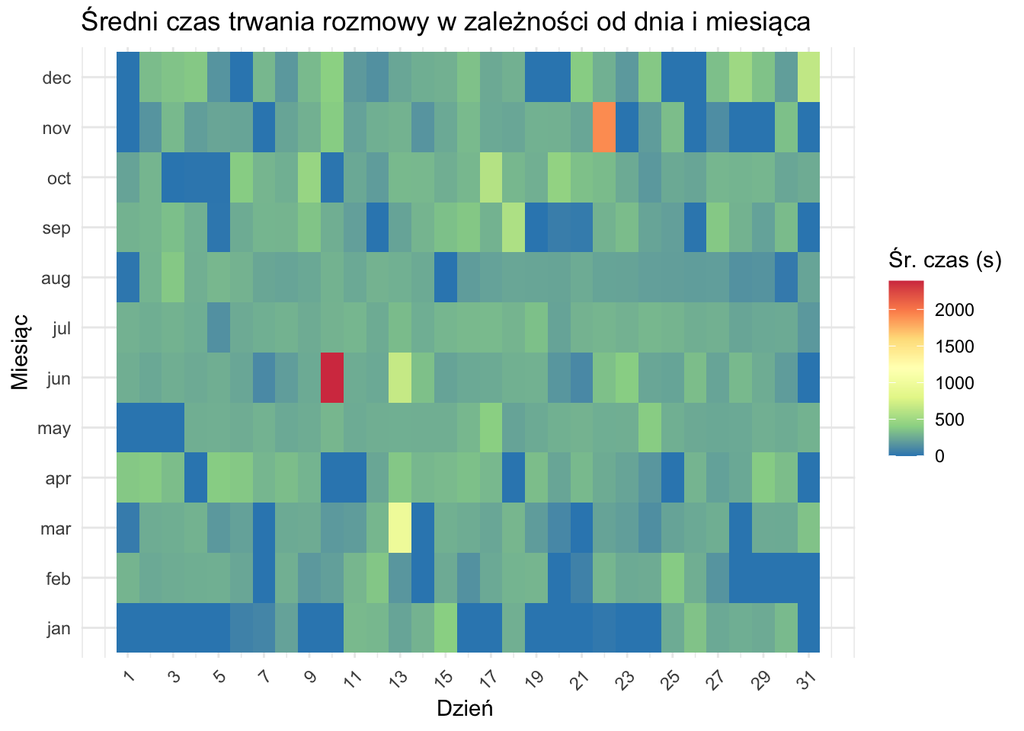

```r
df$month <- factor(df$month, levels = c("jan", "feb", "mar", "apr", "may", "jun",
                                      "jul", "aug", "sep", "oct", "nov", "dec"))
full_grid <- expand_grid(day = 1:31,
                         month = levels(df$month))

avg_duration <- df %>%
  group_by(day, month) %>%
  summarise(mean_duration = mean(duration, na.rm = TRUE), .groups = "drop") %>%
  right_join(full_grid, by = c("day", "month")) %>%
  mutate(mean_duration = replace_na(mean_duration, 0),
         month = factor(month, levels = c("jan", "feb", "mar", "apr", "may", "jun",
                                          "jul", "aug", "sep", "oct", "nov","dec")))


ggplot(avg_duration, aes(x = day, y = month, fill = mean_duration)) +
  geom_tile() +
  scale_fill_distiller(palette = "Spectral") +
  labs(title = "Średni czas trwania rozmowy w zależności od dnia i miesiąca",
       x = "Dzień ",
       y = "Miesiąc",
       fill = "Śr. czas (s)") +
  theme_minimal() +
  scale_x_continuous(breaks = seq(1,31,2)) +
  theme(axis.text.x = element_text(angle = 45, hjust = 1))
```

**Komentarz:**

W większości przypadków średni czas rozmowy utrzymuje się na podobnym poziomie. Możemy zauważyć, że w styczniu rozmowy srednio trwaja najkrócej, a najdluższe są w czerwcu.

Chociaż w niektórych dniach i miesiącach występują pojedyncze, dłuższe rozmowy, to nie widać silnego związku między dniem i miesiącem kontaktu a średnim czasem trwania rozmowy.

## Zadanie 5

Czy jest zależnośc pomiędzy wiekiem klientów a ich średnim rocznym saldzie w euro w podziale na stopień wykształcenia?

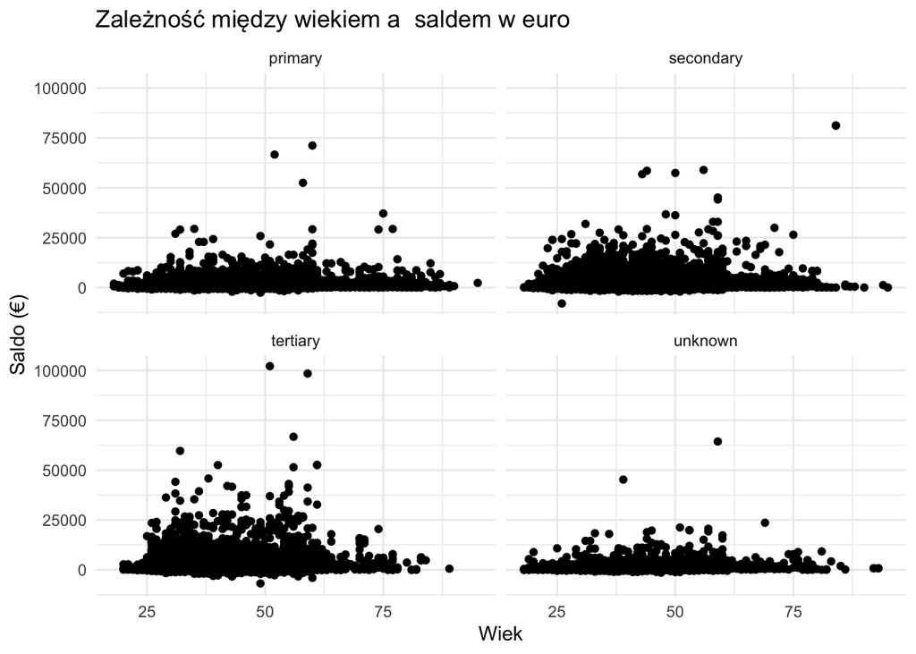

```r
ggplot(df, aes(x = age, y = balance)) +
  geom_point() +
  facet_wrap(~ education) +
  theme_minimal() +
  labs(title = "Zależność między wiekiem a  saldem w euro",
       x = "Wiek",
       y = "Saldo (€)",
       color = "Wykształcenie")
```

**Komentarz:**

Grupa z wykształceniem wyższym (“tertiary”) posiada największą liczbę klientów z wysokim saldem, posiadaja je osoby w przedziale wiekowym 30-60 lat.

W pozostałych grupach salda są znacząco niższe i układają się równomiernie bez większego wpływu wieku.

## Zadanie 6

Rozważmy osoby, które są bezrobotne albo ich zawód jest nieznany. Czy procent osób, które są bezrobotne i nie spłacają kredytu jest większy od procenta osób o nieznanym zawodzie i nie spłacanym kredycie? Jaki typ kredytu jest (przez te osoby) najczęściej niespłacany?

```r
  zad_6 <- df %>%
  filter(job %in% c("unemployed", "unknown")) %>%
  filter(loan =="yes" | housing=="yes") %>%
  group_by(job) %>%
  summarise(
    total = n(),
    default_count = sum(default == "yes", na.rm = TRUE),
    default_rate = (default_count / total) * 100,
    housing_count = sum(default == "yes" & housing == "yes", na.rm = T),
    loan_count = sum(default == "yes" & loan == "yes", na.rm = T))

kable(zad_6, caption = "Procent osób, które nie spłacają kredytu w grupie osób bezrobotnych i o nieznanym zawodzie")
```

Procent osób, które nie spłacają kredytu w grupie osób bezrobotnych i o nieznanym zawodzie

| job | total | default_count | default_rate | housing_count | loan_count |
| --- | --- | --- | --- | --- | --- |
| unemployed | 589 | 22 | 3.735144 | 20 | 7 |
| unknown | 28 | 1 | 3.571429 | 1 | 0 |

**Komentarz:**

Procent osób, które nie spłacają kredytu, jest nieznacznie wyższy w grupie osób bezrobotnych (3,73%) niż w grupie osób o nieznanym zawodzie (3,57%).

W obu grupach częściej niespłacany jest kredyt mieszkaniowy.